# act_report

### Dogs rated on WeRateDogs

```python
# import image module
from IPython.display import Image

# Get image of dog
Image(url="https://pbs.twimg.com/media/CT4udn0WwAA0aMy.jpg", width=300, height=300)
```

[figure not shown]

### Introduction

Tweet archive of WeRateDogs, a twitter account that rates dogs with funny comments was used to generate this report. The dataset was made available by the Udacity course instructors. Additional datasets were obtained using the request library in Python to parse data set of dog image predictions from a website. The image predictions were facilitated by a neural network. Also, a JavaScript Object Notation (JSON) file was requested using the tweepy library in Python. Data variables including the ID of the tweet, retweet count, favourite count, and whether or not the tweet was retweeted was read from the JSON file into a data frame. The three datasets were assessed and cleaned prior to analysing and visualising.

### Analyzing and Visualizing Data

Three insights and two visualisations were generated using a cleaned combined dataset.

#### Q1. What is the commonest source of tweets for rating dogs

Majority of tweets were from Iphones. Twitter for the iPhone was the most common source of tweets for rating dogs, followed by Vine-Make a scene, Twitter Web Client, and TweetDeck.

#### Q2. What names are frequently used in terms of dog names?

Charlie and Lucy are the most common dog names among dogs rated on WeRateDogs.

#### Q3. What are the least common names of dogs on WeRateDogs?

Less frequent dog names include Rose, Aubie, Kota, Leela, Glenn, Shelby, Sephie, Bonaparte, Wishes, and Christopher.

#### Visualisation of top ten dog names on WeRateDogs

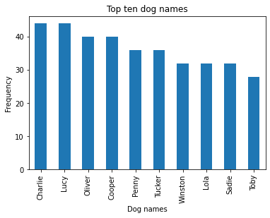

```python
# Libraries imported
import pandas as pd
import matplotlib.pyplot as plt

# Read dataset
df_combined = pd.read_csv("twitter_archive_master.csv")

# Bar chart of dog names- first ten
df_combined["name"].value_counts()[0:10].plot(kind = "bar")
plt.title("Top ten dog names")
plt.xlabel("Dog names")
plt.ylabel("Frequency");
```

#### Visualisation of less common dog names

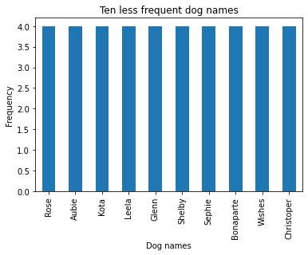

```python
# Bar chart of dog names- last ten
df_combined["name"].value_counts()[-10:].plot(kind = "bar")
plt.title("Ten less frequent dog names")
plt.xlabel("Dog names")
plt.ylabel("Frequency");
```